# TA3 : learning pipe

TA course: Mar.22.2018,Lai

## What’s magrittr ?

> The magrittr (to be pronounced with a sophisticated french accent) is a package with two aims: to decrease development time and to improve readability and maintainability of code. Or even shortr: to make your code smokin’ (puff puff)!  
> To archive its humble aims, magrittr (remember the accent) provides a new “pipe”-like operator, %>%, with which you may pipe a value forward into an expression or function call; something along the lines of x %>% f, rather than f(x).  
> source : https://cran.r-project.org/web/packages/magrittr/vignettes/magrittr.html

簡單說，pipe operator是一個傳遞數值或物件的方法，它能讓你的程式變得優雅易讀， 但未必會增加運行速度。  
另外，pipe operator也應用於許多重要套件如ggplot2、dplyr之中，可以說是進階R技巧的一堂必修課。

## Using pipe operator ‘%>%’

舉例而言，若你想要產生50個$N(\mu＝3,\sigma^2=25)$，將隨機樣本減去平均數，除以標準差後，用ks.test()檢定其是否來自自由度為一的卡方分配，比較一下使用%>% 與不使用的程式碼

```r
library(magrittr)
### without pipe operator:
set.seed(689)
n = (rnorm(50,3,5)-3)/5
ks.test(n,"pchisq",1)$p.value
```

```
## [1] 8.881784e-16
```

```r
### with pipe operator
# subtract(3) 也可寫成 '-'(3)
set.seed(689)
rnorm(50,3,5) %>% subtract(3) %>% divide_by(5) %>% ks.test("pchisq",1) %>% .$p.value
```

```
## [1] 8.881784e-16
```

是不是清楚多了呢？ pipe operator 可以預防函數大腸包小腸的情形，尤其在一連串的複雜處理中特別有效。

假設妳有一個學生成績的字串，若要計算同學的平均

```r
demo = "Amy_73/Tom_44/Alice_63/John_88/Alex_90/Tim_64"

### normally we'll do:
str_list = strsplit(demo,'[/,_]') # split string by '/' or '_' and return list
grade = str_list[[1]][seq(2,length(str_list[[1]]),2)]
mean(as.numeric(grade)) # chnage grade from string to number
```

```
## [1] 70.33333
```

```r
### in one line:
mean(as.numeric(strsplit(demo,'[/,_]')[[1]][seq(2,12,2)]))
```

```
## [1] 70.33333
```

```r
### with %>%
demo %>% strsplit(.,'[/,_]') %>% .[[1]] %>% .[seq(2,12,2)] %>%
  as.numeric() %>% mean()
```

```
## [1] 70.33333
```

## Using pipe operator ‘%$%’

注意再傳送過程中，可以用.來表示傳送的數值，例如：

```r
Orange %>% .[.$Tree==1,3] %>% diff()
```

```
## [1] 28 29 28  5 22  3
```

或者使用 %$%，則會一併把左側物件的名字(name)傳到右側：

```r
Orange %$% .[Tree==2,3] %>% diff()
```

```
## [1] 36 42 45 16 31  0
```

也可以與迴圈結合，分組計算差分，簡直潮到出水：

```r
Orange %$% for(i in 1:3){
  print( .[Tree==i,3] %>% diff() )
}
```

```
## [1] 28 29 28  5 22  3
## [1] 36 42 45 16 31  0
## [1] 21 24 33  7 24  1
```

## Using pipe operator ‘%T>%’

另一個有趣的運算子是%T>%，他可以將物件傳到右側運算後，不回傳右側的值，在使用繪圖函數時特別有用。舉例而言，使用hist() 繪製直方圖時，這個函數會回傳一個“histogram”類別的list，所以下面的code會將原始數據丟失：

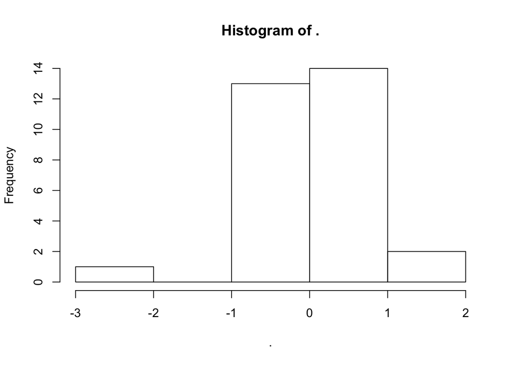

```
## $breaks
## [1] -3 -2 -1  0  1  2
##
## $counts
## [1]  1  0 13 14  2
##
## $density
## [1] 0.03333333 0.00000000 0.43333333 0.46666667 0.06666667
##
## $mids
## [1] -2.5 -1.5 -0.5  0.5  1.5
##
## $xname
## [1] "."
##
## $equidist
## [1] TRUE
##
## attr(,"class")
## [1] "histogram"
```

```r
(temp = rnorm(30) %>% hist())
```

若使用%T>%即可以改善此問題

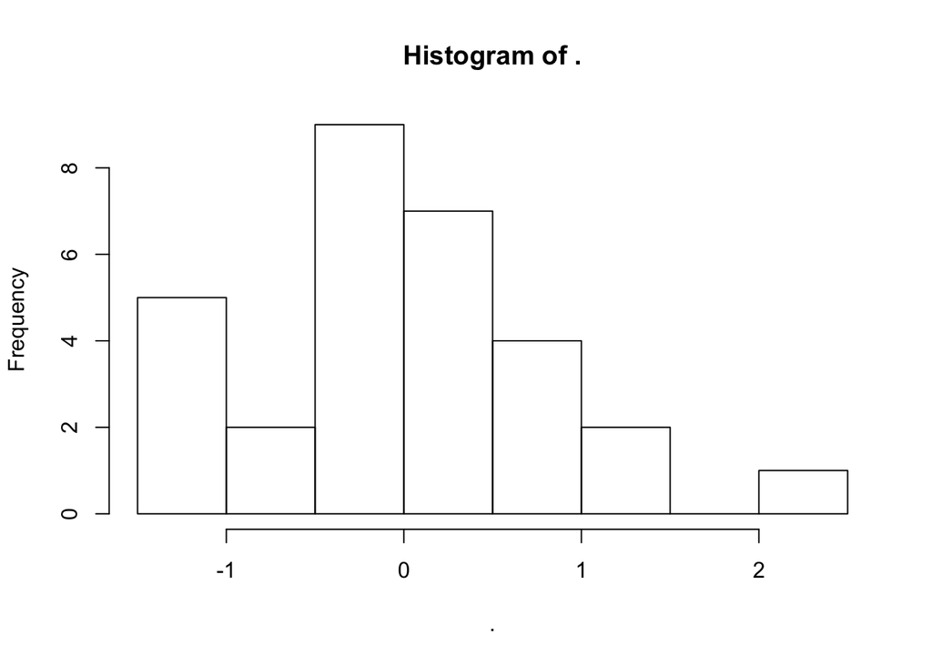

```
##  [1] -0.325315871 -0.284295288 -1.025522415 -0.004681137 -0.137162493
##  [6]  0.578746142 -0.482930821 -1.211018880  0.194985275 -0.321551821
## [11]  0.896720421 -1.319905043  0.122129266  0.025395477  0.114665447
## [16]  0.034681423 -0.926641963 -1.155895283  2.090689526  1.465942586
## [21]  0.020651560 -1.382637722 -0.310918495  0.484323268 -0.016556813
## [26] -0.946366577  0.714423956  0.903761104  1.076255673 -0.251293239
```

```r
(temp =rnorm(30) %T>% hist() )
```

甚至可以串接使用

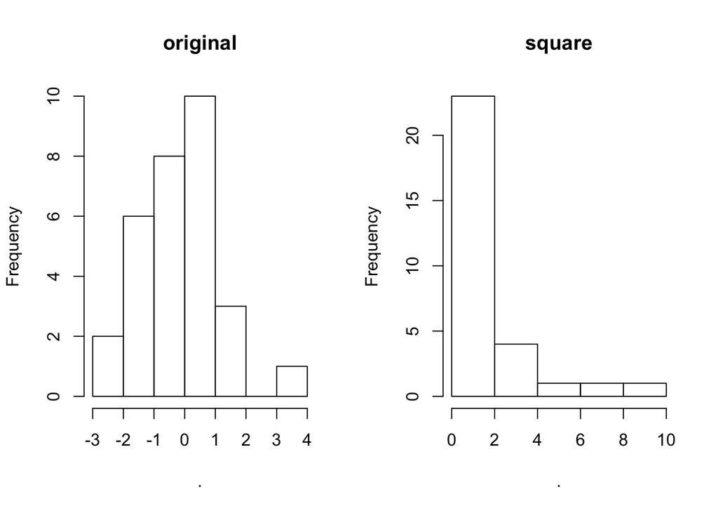

```
##  [1] 1.538220718 0.002510797 0.172194268 2.073014471 2.311408981
##  [6] 0.945063690 0.179611435 0.640242341 3.081498915 1.337791366
## [11] 0.444451711 0.603178256 0.038533774 0.300814686 3.128003914
## [16] 0.186692116 0.421867975 1.225030147 0.539069883 6.818646718
## [21] 1.449798234 0.273990356 0.489299543 0.085001474 1.277401929
## [26] 0.103650912 0.165927144 9.099118368 5.790706252 0.298712562
```

```r
par(mfrow=c(1,2))
(temp = rnorm(30) %T>% hist(,main="original") %>%
    '^'(2) %T>% hist(,main="square"))
```

## 東森的話

pipe operator 真的是寫R code的一大利器，不但增加你的寫扣速度，減少行數與不必要的變數宣告，更讓你的扣的又美又優雅。不過切記不要走火入魔，什麼都要pipe一波，請在維持易讀性的前提下使用。

```r
#走火入魔
lm1 = data.frame(a<-rnorm(30,2,5),b=a^2) %$%
  lm(a~(a %>% exp())+b+(a^3 %>% abs()),data=.)
```

## Reference

1. https://cran.r-project.org/web/packages/magrittr/vignettes/magrittr.html
2. https://www.ptt.cc/bbs/R_Language/M.1437452331.A.CD1.html